# Amirali Rahimi 810100146

# CA5 - Convolutional Neural Network

# Problem Description

In this problem we are have brain MRIs which has been categorized to four classes: `glioma`, `meningioma`, `notumor` and `pituitary`. We are going to use this dataset and implement a convolutional neural network to learn to classify the given MRI.

```python
from google.colab import drive
import torch
import torch.nn as nn
import torch.nn.functional as F
import torch.optim as optim
from torch.utils.data import Dataset
from torchvision import transforms
from torch.utils.data import random_split
from torch.utils.data import Subset
from torch.utils.data import DataLoader
import os
import pandas as pd
import seaborn as sns
from torchvision.io import read_image
import numpy as np
from sklearn.model_selection import StratifiedShuffleSplit
from sklearn.metrics import classification_report, accuracy_score, confusion_matrix
import matplotlib.pyplot as plt
from PIL import Image
```

```python
drive.mount('/content/drive')
dataSetFolder = '/content/drive/MyDrive/AI-CA5-Dataset'
```

## Data Preprocessing

Here we load our data to a customized dataset named `BrainImageDataset`. The preprocessing includes 2 steps:

`Normalization` in CNNs refers to scaling input data to a standard range. Here are the `pros` and `cons`:

`Pros`:

- *Stabilizes Training*: Normalization can speed up convergence during training by helping the optimization algorithm reach the minimum faster.
- *Handles Diverse Data*: It makes the model less sensitive to differences in the scale and distribution of input features.
- *Reduces Vanishing/Exploding Gradients*: It helps prevent extreme weight updates that can hinder training stability.

`Cons`:

- *Loss of Information*: Normalization might remove some specific characteristics of the data, potentially affecting model performance.
- *Sensitivity to Hyperparameters*: The effectiveness of normalization can depend on the chosen normalization technique and parameters.
- *Overfitting Risk*: In some cases, normalization methods can increase the risk of overfitting the model to the training data.

```python
label_to_index = {}  # Mapping string labels to numerical indices

class BrainImageDataset(Dataset):
    def __init__(self, img_dir, transform=None):
        self.img_labels = []
        self.img_dir = img_dir
        self.transform = transform

        index_counter = 0
        for root, dirs, files in os.walk(img_dir):
            for file in files:
                if file.endswith('.jpg') or file.endswith('.png') or file.endswith('.jpeg'):
                    path = os.path.join(root, file)
                    label = os.path.basename(root)
                    if label not in label_to_index:
                        label_to_index[label] = index_counter
                        index_counter += 1
                    self.img_labels.append((path, label_to_index[label]))

    def __len__(self):
        return len(self.img_labels)

    def __getitem__(self, idx):
        img_path, label = self.img_labels[idx]
        image = Image.open(img_path).convert('RGB')
        if self.transform:
            image = self.transform(image)

        return image, label
```

```python
transform = transforms.Compose([
    transforms.Resize((512, 512)),
    transforms.ToTensor(),
    # transforms.Normalize(mean=[0.485, 0.456, 0.406], std=[0.229, 0.224, 0.225])
])

dataset = BrainImageDataset(img_dir=dataSetFolder, transform=transform)
labels = [label for _, label in dataset.img_labels]
sss = StratifiedShuffleSplit(n_splits=1, test_size=0.2, random_state=42)
train_indices, test_indices = next(sss.split(np.zeros(len(labels)), labels))

train_dataset = Subset(dataset, train_indices)
test_dataset = Subset(dataset, test_indices)
```

Here, we count how many images exists in every class of our dataset

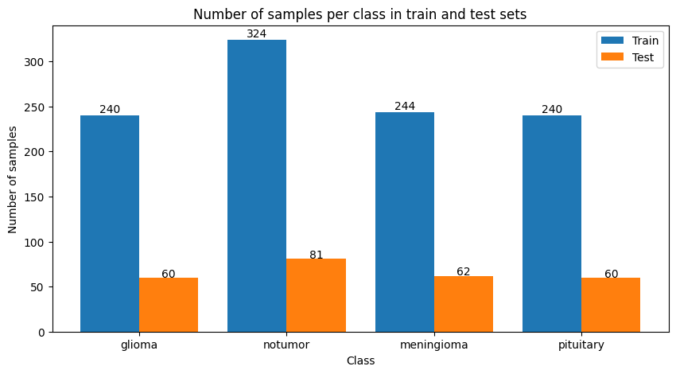

```python
classes = sorted(set(label for _, label in dataset.img_labels))
train_counts = {classname: 0 for classname in classes}
test_counts = {classname: 0 for classname in classes}

for idx in train_indices:
    _, label = dataset.img_labels[idx]
    train_counts[label] += 1

for idx in test_indices:
    _, label = dataset.img_labels[idx]
    test_counts[label] += 1

plt.figure(figsize=(10, 5))
train_bar_positions = np.arange(len(classes))
test_bar_positions = train_bar_positions + 0.4

train_bar_heights = [train_counts[classname] for classname in classes]
test_bar_heights = [test_counts[classname] for classname in classes]

plt.bar(train_bar_positions, train_bar_heights, width=0.4, label='Train')
plt.bar(test_bar_positions, test_bar_heights, width=0.4, label='Test')


class_names = [next(key for key, value in label_to_index.items() if value == class_idx) for class_idx in classes]
plt.xticks(train_bar_positions + 0.2, class_names)

plt.xlabel('Class')
plt.ylabel('Number of samples')
plt.title('Number of samples per class in train and test sets')

plt.legend()

for i in range(len(classes)):
    plt.text(train_bar_positions[i], train_bar_heights[i] + max(train_bar_heights) * 0.01, str(train_bar_heights[i]), ha='center')
    plt.text(test_bar_positions[i], test_bar_heights[i] + max(test_bar_heights) * 0.01, str(test_bar_heights[i]), ha='center')

plt.show()
```

And finally, we show first image of every class.

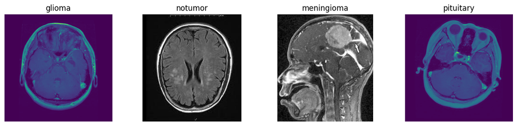

```python
plt.figure(figsize=(15, 8))
for i, classIdx in enumerate(classes):
    class_indices = [idx for idx, (_, label) in enumerate(dataset.img_labels) if label == classIdx]
    first_image_index = class_indices[0]

    first_image_path, _ = dataset.img_labels[first_image_index]
    image = Image.open(first_image_path)

    plt.subplot(3, 5, i + 1)
    plt.imshow(image)
    classname = next(key for key, value in label_to_index.items() if value == classIdx)
    plt.title(classname)
    plt.axis('off')

plt.tight_layout()
plt.show()
```

# Model Architecture Explanation

## Kernel Size

Kernel size is the dimension of the filters used in convolutional layers, impacting the receptive field of neural activations and the level of detail captured:

- Larger kernels (e.g., 11x11 in the first conv layer) capture more global features and reduce spatial dimensions significantly.
- Smaller kernels (e.g., 5x5 and 3x3 in subsequent layers) capture fine-grained features and are standard in deeper layers.

## Stride

Stride dictates the movement of the filter across the input:

- A larger stride (4 in the first conv layer) provides downsampling, reducing the dimensionality of the data.
- A smaller stride (1 in deeper conv layers) maintains spatial resolution, which is important for learning detailed features.

## Padding

Padding is used to add zeros around the input perimeter to allow convolutions at the data edge:

- "Same" padding is employed in your model's second and subsequent layers to maintain the spatial dimensions post-convolution.
- The first convolutional layer does not use padding, reducing the feature map size more than layers with padding.

## Number of Filters

The number of filters in a conv layer corresponds to the amount of detected feature types:

- Initial layers use fewer filters (96), capturing primary features.
- Deeper layers increase the number of filters (up to 384), allowing for more complex feature representation.

## Depth of the Network

Network depth refers to the number of layers:

- A deeper network can represent more complex and abstract features.
- Care must be taken to balance depth with training data availability and computational resources to avoid issues like vanishing gradients.

## Number of Neurons

Neurons in a layer determine the representational capacity:

- Your fully connected layers have a substantial number of neurons (4096), providing high learning capacity.
- While a higher number of neurons can predict better, it can also lead to overfitting, which is a consideration in your model design.

## Activation Functions

Activation functions are non-linear operations that introduce complexity and enable neural networks to learn a wide range of phenomena. Here's a brief overview of some commonly used activation functions:

## ReLU (Rectified Linear Unit)

- **Expression**: `f(x) = max(0, x)`
- **Properties**:
  - Non-linear function that allows the model to account for interactions and non-linear phenomena.
  - Computationally efficient which makes it widely used in deep learning.
  - Helps mitigate the vanishing gradient problem.
  - Can lead to dead neurons during training if not implemented with care (dying ReLU problem).

## Leaky ReLU

- **Expression**: `f(x) = x if x > 0 else ax`
  - `a` is a small constant value.
- **Properties**:
  - Attempts to fix the problem of dying neurons encountered with ReLU.
  - Allows a small, non-zero gradient when the unit is inactive (i.e., output is less than zero).

## Sigmoid

- **Expression**: `f(x) = 1 / (1 + e^(-x))`
- **Properties**:
  - Squashes the input values to a range between 0 and 1.
  - Historically used for binary classification in the final layer (e.g., logistic regression).
  - Suffers from the vanishing gradient problem and is not used often in deep networks.

## Tanh (Hyperbolic Tangent)

- **Expression**: `f(x) = tanh(x)`
- **Properties**:
  - Similar to sigmoid but outputs range from -1 to 1.
  - Zero-centered making it more efficient in backpropagation compared to the sigmoid function.
  - Still can face vanishing gradient problems in deep networks.

## Softmax

- **Expression**: $$f(x_i) = \frac{e^{x_i}}{\sum_{j=1}^{K} e^{x_j}}$$
  - Applied over all `K` classes for multiclass classification.
- **Properties**:
  - Outputs a probability distribution over `K` different possible outcomes.
  - Often used in the output layer for classification problems.

# CNN Architechture

The `CNNModel` class defines a Convolutional Neural Network (CNN) inspired by the well-known `AlexNet`.

### Structure of CNNModel

The structure of `CNNModel` consists of two main parts: `features` and `classifier`.

#### Features

The `features` block is a sequential container that consists of multiple convolutional layers followed by ReLU activation functions and max pooling layers. These layers together are responsible for extracting a hierarchy of features from the input images.

Max pooling layers are used to reduce the spatial dimensions (width and height) of the feature maps, thus providing a form of translation invariance and reducing the computational complexity for the following layers.

Here's a breakdown of the layers in the `features` block:

- **Convolutional Layer 1**: Uses 96 kernels of size 11x11 with a stride of 4 and no padding. It extracts low-level features such as edges and textures from the input image.
- **Convolutional Layer 2**: Increases the depth to 256 using kernels of size 5x5 with padding of size 2. This layer captures more complex features.
- **Convolutional Layer 3 to 5**: These layers use 384 and 256 kernels of size 3x3 with padding of size 1 to further refine and extract high-level abstract features from the input provided by the previous layers.

#### Classifier

The `classifier` block is a sequential container that flattens the feature maps resulting from the `features` block and passes them through three fully connected layers.

Here's the structure:

- **Flatten**: Converts the 3D feature maps into 1D feature vectors.
- **Fully Connected Layer 1**: Transforms the high-dimensional feature vector into a vector of size 4096.
- **Fully Connected Layer 2**: Another layer of size 4096 which helps the network to capture complex patterns and adds stability to the model.
- **Fully Connected Layer 3**: The final layer with a number of output units equal to the number of classes (`num_classes`) for classification.

### Forward Pass

The `forward` method defines the forward pass of the network. It takes an input image tensor `x`, applies the `features` block to extract features, and then applies the `classifier` block to output the final classification results.

### Dummy Input Handling

To determine the number of features before the classifier block, we pass a dummy input through the `features` block and calculate the resulting shape. This helps in determining the correct input size for the first fully connected layer.

### Activation functions and Pooling

In this network, ReLU activation functions are used for introducing non-linearity after each convolutional and fully connected layer, without increasing the model's complexity significantly.

Max Pooling is applied after certain convolutional layers to reduce dimensions, which also helps in avoiding overfitting.

```python
class CNNModel(nn.Module):
    def __init__(self, num_classes=4):
        super(CNNModel, self).__init__()
        self.features = nn.Sequential(
            nn.Conv2d(3, 96, kernel_size=11, stride=4, padding=0),
            nn.ReLU(),
            nn.MaxPool2d(kernel_size=3, stride=2),

            nn.Conv2d(96, 256, kernel_size=5, stride=1, padding=2),
            nn.ReLU(),
            nn.MaxPool2d(kernel_size=3, stride=2),

            nn.Conv2d(256, 384, kernel_size=3, stride=1, padding=1),
            nn.ReLU(),

            nn.Conv2d(384, 384, kernel_size=3, stride=1, padding=1),
            nn.ReLU(),

            nn.Conv2d(384, 256, kernel_size=3, stride=1, padding=1),
            nn.ReLU(),
            nn.MaxPool2d(kernel_size=3, stride=2),
        )

        with torch.no_grad():
            dummy_input = torch.autograd.Variable(torch.zeros(1, 3, 512, 512))
            dummy_output = self.features(dummy_input)
            out_features = dummy_output.shape[1] * dummy_output.shape[2] * dummy_output.shape[3]

        self.classifier = nn.Sequential(
            nn.Flatten(),
            nn.Linear(out_features, 4096),
            nn.ReLU(),
            nn.Linear(4096, 4096),
            nn.ReLU(),
            nn.Linear(4096, num_classes),
        )

    def forward(self, x):
        x = self.features(x)
        x = self.classifier(x)
        return x
```

## Loss Functions for CNNs

1. **Cross-Entropy Loss (or Log Loss):**
   - Commonly used for `classification` tasks.
   - Suitable when dealing with `multiple` classes.
   - Encourages the model to assign high probability to the correct class. $$CrossEntropy = - \sum_{i=1}^{C} target_i \log(predicted_i)$$
2. **Mean Squared Error (MSE):**
   - Often used for `regression` problems.
   - Measures the average squared difference between predicted and actual values.
   - Useful when predicting continuous values. $$MSE = \frac{1}{n} \sum_{i=1}^{n} ( predicted_i - target_i )^2$$
3. **Binary Cross-Entropy Loss:**
   - Specifically used for `binary classification` problems.
   - Similar to cross-entropy but tailored for binary class scenarios. $$BCE = - \left( target* \log(predicted) + (1 - target) \log(1 - predicted) \right)$$

Based on what you read, `Cross-Entropy Loss looks better` for this classifcation.

## Adam Optimizer for CNN

**Adam (Adaptive Moment Estimation) Optimizer**:

- Adaptive learning rate optimization algorithm for training neural networks.
- Combines the advantages of two other extensions of stochastic gradient descent (SGD): Adaptive Gradient Algorithm (AdaGrad) and Root Mean Square Propagation (RMSProp).
- Maintains per-parameter learning rates that are adapted based on the average of past gradients and their squared gradients.

**Differences between Adam and SGD**:

- **Learning Rate:** Adam dynamically adjusts the learning rate for each parameter, while in SGD, a single learning rate is used for all parameters.
- **Adaptiveness:** Adam adapts the learning rate for each parameter over time, providing adaptive momentum, whereas SGD uses a fixed momentum.
- **Convergence Speed:** Adam often converges faster than SGD due to its adaptive learning rate.

**Advantages of Using Adam**:

- Faster convergence compared to traditional SGD.
- Well-suited for problems with large datasets or high-dimensional parameter spaces.
- Robust performance across various neural network architectures and hyperparameters.

## Batch Size in CNN and Its Effects on Learning

- **Training Speed:** Larger batch sizes process more samples simultaneously, leveraging hardware parallelism (e.g., GPUs) for faster training.
- **Generalization:** Smaller batch sizes introduce noise, acting as a regularizer for potentially better generalization. Larger batch sizes might contribute to overfitting or convergence to sharp minima.
- **Memory Usage:** Larger batch sizes demand more memory, limiting model size or sample capacity in memory, especially on GPUs with limited memory.
- **Stability and Convergence:** Smaller batch sizes introduce more noise, potentially causing slower convergence or oscillations. Larger batch sizes often lead to more stable convergence but may converge to suboptimal solutions.
- **Accuracy and Performance:** Batch size significantly impacts the final accuracy and model performance, varying based on dataset size, network architecture, and problem domain.

Here we've used batch size of 32

```python
train_loader = DataLoader(train_dataset, batch_size=32, shuffle=True)
test_loader = DataLoader(test_dataset, batch_size=32, shuffle=False)

device = torch.device("cuda" if torch.cuda.is_available() else "cpu")
model = CNNModel().to(device)

criterion = nn.CrossEntropyLoss()
optimizer = optim.Adam(model.parameters(), lr=0.001)
```

# Train The Model

We train the model here for 30 epochs, and calculate loss and accuracy of train_data and test_data for every epoch. And then we plot these values.

```python
num_epochs = 30

train_losses = []
train_accuracies = []
test_losses = []
test_accuracies = []

for epoch in range(num_epochs):
    running_loss_train = 0.0
    correct_train = 0
    total_train = 0

    for i,(inputs, labels) in enumerate(train_loader):
      inputs, labels = inputs.to(device), labels.to(device)
      optimizer.zero_grad()
      with torch.set_grad_enabled(True):
        outputs = model(inputs)

      loss = criterion(outputs, labels)
      running_loss_train += loss.item()
      loss.backward()
      optimizer.step()

      _, predicted = torch.max(outputs.data, 1)
      total_train += labels.size(0)
      correct_train += (predicted == labels).sum().item()

      del inputs, labels, outputs
      torch.cuda.empty_cache()

    epoch_loss_train = running_loss_train / len(train_loader)
    epoch_acc_train = correct_train / total_train

    train_losses.append(epoch_loss_train)
    train_accuracies.append(epoch_acc_train)

    running_loss_test = 0.0
    correct_test = 0
    total_test = 0
    with torch.no_grad():
      for images, labels in test_loader:
        images, labels = images.to(device), labels.to(device)

        outputs = model(images)
        loss = criterion(outputs, labels)
        running_loss_test += loss.item()

        _, predicted = torch.max(outputs.data, 1)
        total_test += labels.size(0)
        correct_test += (predicted == labels).sum().item()

        del images, labels, outputs
        torch.cuda.empty_cache()

      epoch_loss_test = running_loss_test / len(test_loader)
      epoch_acc_test = correct_test / total_test

      test_losses.append(epoch_loss_test)
      test_accuracies.append(epoch_acc_test)

    print(f'------Epoch {epoch+1}:')
    print('__TRAIN__')
    print(f'    Accuracy:       {epoch_acc_train:.2%}')
    print(f'    Loss    :       {epoch_loss_train:.4f}')
    print('__TEST__')
    print(f'    Accuracy:       {epoch_acc_test:.2%}')
    print(f'    Loss    :       {epoch_loss_test:.4f}')
```

```
------Epoch 1:
__TRAIN__
    Accuracy:       29.96%
    Loss    :       1.6789
__TEST__
    Accuracy:       23.57%
    Loss    :       1.3854
------Epoch 2:
__TRAIN__
    Accuracy:       26.81%
    Loss    :       1.3711
__TEST__
    Accuracy:       30.80%
    Loss    :       1.3283
------Epoch 3:
__TRAIN__
    Accuracy:       33.97%
    Loss    :       1.3222
__TEST__
    Accuracy:       39.92%
    Loss    :       1.2648
------Epoch 4:
__TRAIN__
    Accuracy:       37.88%
    Loss    :       1.2786
__TEST__
    Accuracy:       30.80%
    Loss    :       1.3722
------Epoch 5:
__TRAIN__
    Accuracy:       35.50%
    Loss    :       1.2999
__TEST__
    Accuracy:       54.75%
    Loss    :       1.0812
------Epoch 6:
__TRAIN__
    Accuracy:       60.40%
    Loss    :       0.9090
__TEST__
```

[output cut: 155 more lines]

```
    Loss    :       1.3163
------Epoch 29:
__TRAIN__
    Accuracy:       98.95%
    Loss    :       0.0308
__TEST__
    Accuracy:       83.27%
    Loss    :       1.4156
------Epoch 30:
__TRAIN__
    Accuracy:       99.52%
    Loss    :       0.0168
__TEST__
    Accuracy:       82.51%
    Loss    :       1.5729
```

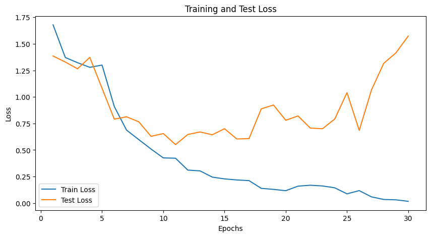

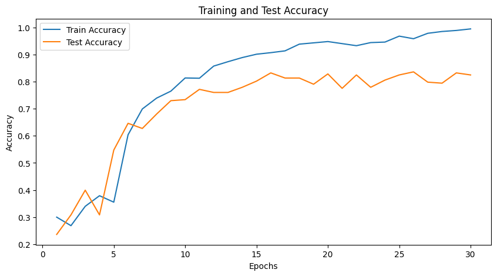

```python
epochs = range(1, num_epochs + 1)

plt.figure(figsize=(10, 5))
plt.plot(epochs, train_losses, label='Train Loss')
plt.plot(epochs, test_losses, label='Test Loss')
plt.xlabel('Epochs')
plt.ylabel('Loss')
plt.title('Training and Test Loss')
plt.legend()
plt.show()

plt.figure(figsize=(10, 5))
plt.plot(epochs, train_accuracies, label='Train Accuracy')
plt.plot(epochs, test_accuracies, label='Test Accuracy')
plt.xlabel('Epochs')
plt.ylabel('Accuracy')
plt.title('Training and Test Accuracy')
plt.legend()
plt.show()
```

## Analyzing the Results

Now we evaluate our model performance on the test_data and calculate values of `Percision`, `Recall`, `Accuracy` and `F1 Score`. and finally visualize the confusion matrix

```
Accuracy: 0.8251
Classification Report:
              precision    recall  f1-score   support

      glioma       0.86      0.70      0.77        60
     notumor       0.93      0.99      0.96        81
  meningioma       0.66      0.69      0.68        62
   pituitary       0.83      0.87      0.85        60

    accuracy                           0.83       263
   macro avg       0.82      0.81      0.81       263
weighted avg       0.83      0.83      0.82       263

Confusion Matrix:
```

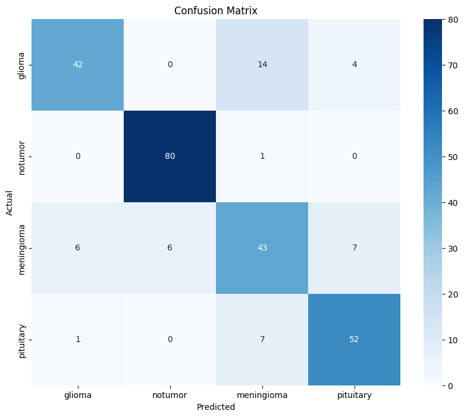

```python
model.eval()
all_predictions = []
all_labels = []

with torch.no_grad():
    for images, labels in test_loader:
        images, labels = images.to(device), labels.to(device)
        outputs = model(images)
        _, predicted = torch.max(outputs, 1)
        all_predictions.extend(predicted.cpu().numpy())
        all_labels.extend(labels.cpu().numpy())

classes = [key for key, _ in sorted(label_to_index.items(), key=lambda item: item[1])]
accuracy = accuracy_score(all_labels, all_predictions)
class_metrics = classification_report(all_labels, all_predictions, target_names=classes)
conf_matrix = confusion_matrix(all_labels, all_predictions)

all_labels = [classes[idx] for idx in all_labels]
all_predictions = [classes[idx] for idx in all_predictions]

print(f"Accuracy: {accuracy:.4f}")
print("Classification Report:")
print(class_metrics)
print("Confusion Matrix:")

conf_matrix_df = pd.DataFrame(conf_matrix, index=classes, columns=classes)
plt.figure(figsize=(10, 8))
sns.heatmap(conf_matrix_df, annot=True, fmt='d', cmap='Blues')
plt.xlabel('Predicted')
plt.ylabel('Actual')
plt.title('Confusion Matrix')
plt.show()
```

## Regularization Methods

### Batch Normalization:

- **Purpose**: Stabilizes and accelerates training by normalizing inputs within each layer.
- **Effects**:
  - **Stabilizes learning**: Reduces internal covariate shift, making training more stable and faster.
  - **Regularization**: Acts as regularization, making networks more robust to overfitting.
  - **Mitigates gradient issues**: Helps prevent vanishing/exploding gradients in deep networks.
  - **Reduces sensitivity to initialization**: Makes networks less sensitive to initialization.

### Dropout:

- **Purpose**: Prevents overfitting by randomly dropping nodes during training.
- **Effects**:
  - **Reduces overfitting**: Prevents reliance on specific activations or features, reducing overfitting.
  - **Encourages robustness**: Promotes learning of more robust features.
  - **Ensemble effect**: Mimics an ensemble of models during training, improving generalization.

```python
class RegularizedCNNModel(nn.Module):
    def __init__(self, num_classes=4):
        super(RegularizedCNNModel, self).__init__()
        self.features = nn.Sequential(
            nn.Conv2d(3, 96, kernel_size=11, stride=4, padding=0),
            nn.ReLU(),
            nn.MaxPool2d(kernel_size=3, stride=2),

            nn.Conv2d(96, 256, kernel_size=5, stride=1, padding=2),
            nn.ReLU(),
            nn.MaxPool2d(kernel_size=3, stride=2),

            nn.Conv2d(256, 384, kernel_size=3, stride=1, padding=1),
            nn.ReLU(),

            nn.Conv2d(384, 384, kernel_size=3, stride=1, padding=1),
            nn.ReLU(),

            nn.Conv2d(384, 256, kernel_size=3, stride=1, padding=1),
            nn.ReLU(),
            nn.MaxPool2d(kernel_size=3, stride=2),
        )
        with torch.no_grad():
            dummy_input = torch.autograd.Variable(torch.zeros(1, 3, 512, 512))
            dummy_output = self.features(dummy_input)
            out_features = dummy_output.shape[1] * dummy_output.shape[2] * dummy_output.shape[3]

        self.classifier = nn.Sequential(
            nn.Flatten(),
            nn.Dropout(0.5),
            nn.Linear(out_features, 4096),
            nn.ReLU(),
            nn.Dropout(0.5),
            nn.Linear(4096, 4096),
            nn.ReLU(),
            nn.Linear(4096, num_classes),
        )

    def forward(self, x):
        x = self.features(x)
        x = self.classifier(x)
        return x
```

```python
device = torch.device("cuda" if torch.cuda.is_available() else "cpu")
model = RegularizedCNNModel().to(device)

criterion = nn.CrossEntropyLoss()
optimizer = optim.Adam(model.parameters(), lr=0.001)
```

```python
num_epochs = 30

train_losses = []
train_accuracies = []
test_losses = []
test_accuracies = []

for epoch in range(num_epochs):
    running_loss_train = 0.0
    correct_train = 0
    total_train = 0

    for i,(inputs, labels) in enumerate(train_loader):
      inputs, labels = inputs.to(device), labels.to(device)
      optimizer.zero_grad()
      with torch.set_grad_enabled(True):
        outputs = model(inputs)

      loss = criterion(outputs, labels)
      running_loss_train += loss.item()
      loss.backward()
      optimizer.step()

      _, predicted = torch.max(outputs.data, 1)
      total_train += labels.size(0)
      correct_train += (predicted == labels).sum().item()

      del inputs, labels, outputs
      torch.cuda.empty_cache()

    epoch_loss_train = running_loss_train / len(train_loader)
    epoch_acc_train = correct_train / total_train

    train_losses.append(epoch_loss_train)
    train_accuracies.append(epoch_acc_train)

    running_loss_test = 0.0
    correct_test = 0
    total_test = 0
    with torch.no_grad():
      for images, labels in test_loader:
        images, labels = images.to(device), labels.to(device)

        outputs = model(images)
        loss = criterion(outputs, labels)
        running_loss_test += loss.item()

        _, predicted = torch.max(outputs.data, 1)
        total_test += labels.size(0)
        correct_test += (predicted == labels).sum().item()

        del images, labels, outputs
        torch.cuda.empty_cache()

      epoch_loss_test = running_loss_test / len(test_loader)
      epoch_acc_test = correct_test / total_test

      test_losses.append(epoch_loss_test)
      test_accuracies.append(epoch_acc_test)

      print(f'------Epoch {epoch+1}:')
      print('__TRAIN__')
      print(f'    Accuracy:       {epoch_acc_train:.2%}')
      print(f'    Loss    :       {epoch_loss_train:.4f}')
      print('__TEST__')
      print(f'    Accuracy:       {epoch_acc_test:.2%}')
      print(f'    Loss    :       {epoch_loss_test:.4f}')
```

```
------Epoch 1:
__TRAIN__
    Accuracy:       32.35%
    Loss    :       1.6876
__TEST__
    Accuracy:       26.62%
    Loss    :       1.3796
------Epoch 2:
__TRAIN__
    Accuracy:       49.43%
    Loss    :       1.1573
__TEST__
    Accuracy:       54.37%
    Loss    :       1.1791
------Epoch 3:
__TRAIN__
    Accuracy:       64.60%
    Loss    :       0.8628
__TEST__
    Accuracy:       63.50%
    Loss    :       0.8506
------Epoch 4:
__TRAIN__
    Accuracy:       70.90%
    Loss    :       0.6908
__TEST__
    Accuracy:       63.50%
    Loss    :       0.7678
------Epoch 5:
__TRAIN__
    Accuracy:       70.99%
    Loss    :       0.6568
__TEST__
    Accuracy:       69.96%
    Loss    :       0.8298
------Epoch 6:
__TRAIN__
    Accuracy:       75.86%
    Loss    :       0.5969
__TEST__
```

[output cut: 155 more lines]

```
    Loss    :       0.8639
------Epoch 29:
__TRAIN__
    Accuracy:       97.04%
    Loss    :       0.0871
__TEST__
    Accuracy:       81.75%
    Loss    :       0.8376
------Epoch 30:
__TRAIN__
    Accuracy:       95.04%
    Loss    :       0.1437
__TEST__
    Accuracy:       79.85%
    Loss    :       0.9370
```

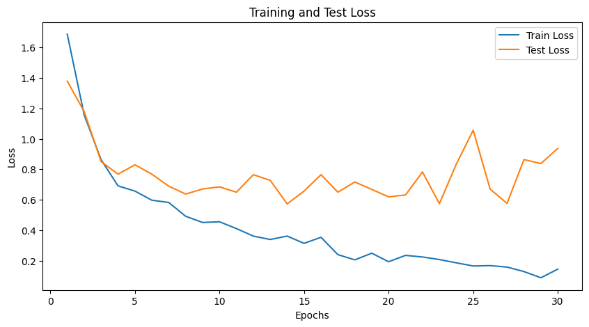

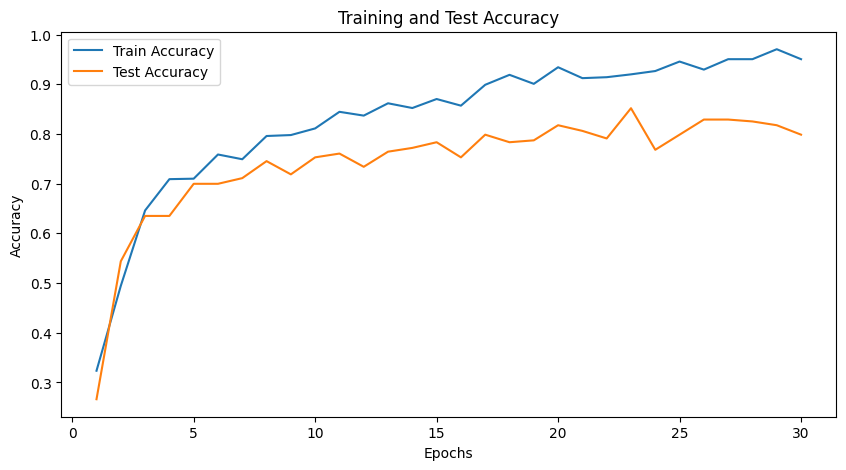

```python
epochs = range(1, num_epochs + 1)

plt.figure(figsize=(10, 5))
plt.plot(epochs, train_losses, label='Train Loss')
plt.plot(epochs, test_losses, label='Test Loss')
plt.xlabel('Epochs')
plt.ylabel('Loss')
plt.title('Training and Test Loss')
plt.legend()
plt.show()

plt.figure(figsize=(10, 5))
plt.plot(epochs, train_accuracies, label='Train Accuracy')
plt.plot(epochs, test_accuracies, label='Test Accuracy')
plt.xlabel('Epochs')
plt.ylabel('Accuracy')
plt.title('Training and Test Accuracy')
plt.legend()
plt.show()
```

```
Accuracy: 0.8479
Classification Report:
              precision    recall  f1-score   support

      glioma       0.79      0.83      0.81        60
     notumor       0.89      0.99      0.94        81
  meningioma       0.81      0.55      0.65        62
   pituitary       0.87      0.98      0.92        60

    accuracy                           0.85       263
   macro avg       0.84      0.84      0.83       263
weighted avg       0.84      0.85      0.84       263

Confusion Matrix:
```

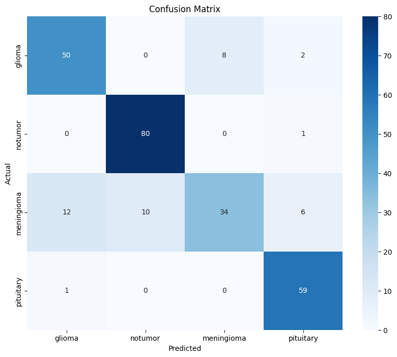

```python
model.eval()
all_predictions = []
all_labels = []

with torch.no_grad():
    for images, labels in test_loader:
        images, labels = images.to(device), labels.to(device)
        outputs = model(images)
        _, predicted = torch.max(outputs, 1)
        all_predictions.extend(predicted.cpu().numpy())
        all_labels.extend(labels.cpu().numpy())

classes = [key for key, _ in sorted(label_to_index.items(), key=lambda item: item[1])]
accuracy = accuracy_score(all_labels, all_predictions)
class_metrics = classification_report(all_labels, all_predictions, target_names=classes)
conf_matrix = confusion_matrix(all_labels, all_predictions)

all_labels = [classes[idx] for idx in all_labels]
all_predictions = [classes[idx] for idx in all_predictions]

print(f"Accuracy: {accuracy:.4f}")
print("Classification Report:")
print(class_metrics)
print("Confusion Matrix:")

conf_matrix_df = pd.DataFrame(conf_matrix, index=classes, columns=classes)
plt.figure(figsize=(10, 8))
sns.heatmap(conf_matrix_df, annot=True, fmt='d', cmap='Blues')
plt.xlabel('Predicted')
plt.ylabel('Actual')
plt.title('Confusion Matrix')
plt.show()
```

As we can see, the overfitting problem is less significant here after adding dropout layer to this model.